# maquinasqueescrevemx

## Máquinas que escrevem

### Do Livro de Daniel, da Bíblia Sagrada, ao ChatGPT, da OpenAI

### Luís Carlos Silva Eiras, janeiro, 2023

### 1 - Bíblia Sagrada, Daniel, século VI a.C.

Durante um banquete do rei Baltazar, uma mão escreve na parede a mensagem secreta *Menê menê tequêl u-parsin*. O profeta e criptólogo Daniel é chamado e decifra mensagem: *contado, pesado e dividido* - a mensagem se refere ao reino de Baltazar. Está na ***Bíblia Sagrada***, no Livro de Daniel, capítulo 5, versículos 5-25, escritos provavelmente no século VI a.C. Em 1635, Rembrandt pintou a cena:

[figure not shown]

```python
from IPython.display import Image
Image('imagens/RembrandtBaltazar.jpg')
```

### 2 - Viagens de Gulliver, Swift, 1726

Na 3ª parte - *Viagem a Laputa, Balnibarbi, Luggnagg, Glubbdubdrib e Japão* - , no Capítulo 5, é descrito um invento que *a pessoa mais ignorante poderia, a um preço razoável e com pequeno trabalho corporal, escrever livros de filosofia, poesia, política, direito, matemática e teologia sem a menor assistência do engenho ou estudo*. Abaixo a versão do tal invento, conforme o desenho de Guido Crepax na paródia (da paródia!) ***Les Voyages de Bianca*** (1983).

[figure not shown]

```python
from IPython.display import Image
Image('imagens/swift.jpg')
```

### 3 - O escrivão, Pierre e Henri-Louis Jacquet-Droz, Jean-Frédéric Leschot, 1773

Um jornal em Berlim publicou, em 1775, que o andróide ***O escrivão*** podia *escrever de modo claro e correto tudo o que é ditado, sem que ninguém o toque*. Na verdade, ***O escrivão***, uma máquina com mecanismo de relojoaria, podia escrever uma única frase curta.

[figure not shown]

```python
from IPython.display import Image
Image('imagens/escrivão.jpg')
```

### 4 - Na colônia penal, Kafka, 1914-1919

É descrita uma “máquina notável” em três partes. Na parte superior fica o escâner, onde é colocada a sentença. No meio, fica o rastelo com suas agulhas de pontas longas para escrever, e as curtas, que jorram água. E na parte debaixo, fica a cama de algodão, onde é amarrado o condenado. A finalidade da máquina é, obviamente, ler a sentença no escâner e escrevê-la nas costas do condenado com as agulhas do rastelo. Apesar de muita elogiada como projeto, a máquina na demonstração não funciona muito bem. Franz Kafka morreu de tuberculose em 1924. Suas irmãs Elli, Valli e Ottla foram assassinadas, de 1941 a 1943, em campos de extermínio. Abaixo a versão da máquina, segundo Crumb, em ***Kafka*** (2000).

[figure not shown]

```python
from IPython.display import Image
Image('imagens/colonia.jpg')
```

### 5 - A Biblioteca de Babel, Borges, 1944

Somente uma máquina ou milhares podem ter escrito os livros da ***Biblioteca de Babel***, de Jorge Luís Borges. A Biblioteca é feita de paredes hexagonais e cada cômodo possui 5 prateleiras, a prateleira 32 livros, o livro 410 páginas, e a página tem 40 linhas, e cada linha 80 letras. As letras são feitas de 25 sinais, e cada livro difere dos que estão ao seu lado em apenas um caractere. Feita a conta (25 caracteres elevado a 80 letras x 40 linhas x 410 páginas) a Biblioteca de Babel possui 25 elevado a 1312000 livros. Ou todos os livros que foram e que serão escritos. Uma biblioteca assim só pode ser construída a partir de uma ou muitas máquinas ligadas a impressoras capazes de produzir livros que, começando com aaaaa...etc. e terminando com zzzzz...etc., tivessem um único caractere de diferença. Borges não descreve essas máquinas, mas a Biblioteca só pode existir a partir delas.

Em tempo: o fichário da ***Biblioteca*** é uma cópia idêntica da ***Biblioteca***.

A ***Biblioteca*** não é infinita. O programa abaixo é capaz de calcular o número de livros da ***Biblioteca de Babel***. Para executar, retire as cerquilhas ou "jogo da velha" (#).

```python
babel = 25**1312000
babel
```

```
195603991760133212910992218835224485467563412651972301442207…
```

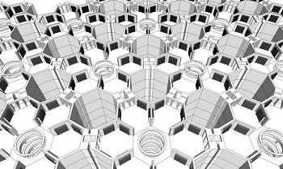

```python
from IPython.display import Image
Image('imagens/babel.jpg')
```

### 6 - Cem bilhões de poemas, Queneau, 1961

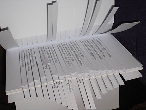

```python
from IPython.display import Image
Image('imagens/queneau.jpg')
```

Abaixo uma versão do ***Cem bilhões de poemas*** com os versos traduzidos do francês pelo Google Tradutor.

```python
%run -i queneau.ipynb
```

```
O cavalo do Parthenon fica chateado com seu friso
Para secar nas pontas dos touros
Ele se inclina e depois para sua surpresa
E tudo passa a significar o fim dos grãos
Ainda me lembro dessa hora requintada
Quem gosta de enganar os pobres provinciais
Da morte nós enxertamos uma ordem bastarda
Quando o gin estraga granizo metralhadora os barcos
Secamos o sargo ou o tamboril
O gato faz um banquete de cabeças de rede
Ele vai querer encontrar o germe adúltero
Você não deveria ter abalado os encantos até agora
As Índias têm pingentes suficientes sem isso
Se a Europa quer a Europa ou o seu destino
```

### 7 - O jogo da amarelinha, Cortázar, 1963

Logo no início de ***O jogo da amarelinha***, em* Tabuleiro de Direção*, Júlio Cortázar sugere como o livro deve ser lido, isto é, a ordem dos 155 capítulos. Assim, deve-se começar pelo capítulo 73 e, em seguida, devem ser lidos os capítulos 1, 2, 116, 3, 84, 4, 71 etc., numerações que também estão no final de cada capítulo. Entretanto, considerando que a ordem dos capítulos pode gerar romances diferentes e caso o leitor não queira obedecer a ordem sugerida por Cortázar, existem - fatorial de 155, 155! - outras combinações possíveis para se ler os 155 capítulos. Por outro lado, como são livres a ordem e a quantidade, o leitor pode ler apenas alguns capítulos e dar o romance como lido.

```python
def main():
    n = int(155)
    fatorial = 1
    i = 2
    while i <= n:
        fatorial = fatorial*i
        i = i + 1
    print("Existem", fatorial, "maneiras de se ler O jogo da amarelinha, de Julio Cortázar.")
main()
```

```
Existem 478914290146339387633577523906302272217629559133776717407009… maneiras de se ler O jogo da amarelinha, de Julio Cortázar.
```

[figure not shown]

```python
from IPython.display import Image
Image('imagens/cortazar.jpg')
```

### 8 - O livro de areia, Borges, 1975

***O livro de areia*** tem este nome, porque os livros e a areia não têm principio nem fim. Cada vez que se abre o tal livro, se tem uma página diferente, que nunca se repete. É possível que o ***O livro de areia*** seja apenas um terminal de boa resolução, já que possui imagens, e acesso aleatórias às paginas dos livros da ***Biblioteca de Babel***.

Quanto escrevo, em fevereiro de 2020, a web tem 1.260.909.305 sites em 254.192.929 domínios hospedados em 9.564.965 servidores, conforme o site https://news.netcraft.com. Caso você esteja lendo depois desta data, o programa abaixo poderá atualizar estes dados.

```python
from bs4 import BeautifulSoup
from urllib.request import urlopen
url = 'https://news.netcraft.com/archives/category/web-server-survey/'
html = urlopen(url)
bs = BeautifulSoup(html, 'lxml')
print(bs.find('div', class_='post__content').text)
```

```
In the December 2022 survey we received responses from 1,125,374,532 sites across 271,238,722 domains and 12,234,425 web-facing computers. This reflects a loss of 9.7 million sites, 450,421 domains, and 72,200 web-facing computers.
Cloudflare continues its growth, gaining 1.5 million sites (+1.44%) and 309,670 domains (+1.21%). Cloudflare now accounts for 9.14% of sites and 9.57% of domains seen by Netcraft, up by 0.21pp and 0.13pp respectively.
Apache lost 7.4 million sites (-3.03%) and 15,439 web-facing computers (-0.46%). However, it saw a modest gain of 52,986 domains (+0.09%). nginx also saw significant loss of 5.5 million sites (-1.84%), 1.3 million domains (-1.77%), and 82,128 web-facing computers (-1.71%).
The largest percentage growth this month comes from LiteSpeed, with it gaining 1.1 million sites (+2.01%) and 170,873 domains (+2.03%). OpenResty also saw a significant growth of 1.1 million sites (+1.20%) but lost 135,748 domains (-0.34%).
In the top million busiest sites, Cloudflare continues its upward trend - gaining 809 of the top million sites, which increases its market share by 0.08pp to 21.08%. The gap between Cloudflare and the leader Apache, which lost 784 sites and 0.08pp market share, is down to just 0.51pp. In second plac…
Vendor news

njs 0.7.9, the scripting language used to extend nginx, was released on 17th November 2022 with various bugfixes.
Apache Tomcat versions 9.0.69 and 10.1.2 were released on 14th November 2022. Version 8.5.84 was released on 21st November 2022. All of these releases mostly contain bugfixes.
AWS announced the new Europe (Zurich), Europe (Spain), and Asia Pacific (Hyderabad) Regions, bringing the total number of AWS Regions to 30. It also announced new Local Zones and various new features at AWS re:Invent 2022.








DeveloperNovember 2022PercentDecember 2022PercentChange
nginx300,890,89126.51%295,366,78326.25%-0.26
Apache242,899,32421.40%235,541,40820.93%-0.47
Cloudflare101,367,8898.93%102,829,7469.14%0.21
OpenResty91,612,7998.07%92,711,2938.24%0.17

Continue reading
```

### 9 - O negociante de inícios de romance, Visniec, 2015

No capítulo 51, aparece o programa EASY TELLER (assim mesmo em maiúsculas), que escreve romances. O programa é um chatboot que, depois de conversar os detalhes do futuro romance a ser escrito para o autor (autor?), gera o capítulo 52. E no capítulo 53, o EASY TELLER vende um upgrade, o *Patch*.

[figure not shown]

```python
from IPython.display import Image
Image('imagens/negociante.jpg')
```

### 10 - Literai, Fiction Written by Computers, O'Neill, Voutas, Lamego, Zou, 2016

No site ***Literai*** (https://www.literai.com) existem vários exemplos de ficção escrita por computadores. O site ensina também nos tutoriais como baixar, instalar o modelo *project.t7* para gerar uma nova história a partir de um texto, e publicá-la no próprio site. O *project.t7* utiliza uma rede neural LSTM.

[figure not shown]

```python
from IPython.display import Image
Image('imagens/literai.jpg')
```

### 11 - Baterias de íon de lítio. Um resumo gerado por máquina das pesquisas atuais, Springer Nature, 2019

Henning Schoenenberger (humano), da editora acadêmica ***Springer Nature***, diz, na introdução, que esse é primeiro livro de pesquisa gerado pelo aprendizado de máquina. Como nos últimos 3 anos foram publicados mais de 53 mil artigos sobre o assunto, o que torna impossível seu estudo, o livro traz um resumo automático de 1.086 dessas publicações. Uma redução a níveis humanos de entendimento.

Na introdução, Schoenenberger explica ainda as várias etapas do processamento de linguagem natural, que tornaram o livro possível. O livro pode ser copiado gratuitamente em https://link.springer.com/book/10.1007/978-3-030-16800-1

[figure not shown]

```python
from IPython.display import Image
Image('imagens/lítio.jpg')
```

### 12 - GPT-2, OpenAI. Talk to Transformer, Adam Daniel King, 2019

Em novembro de 2019, o site ***OpenAI***, de Elon Musk, divulgou o* GPT-2*, um gerador de texto capaz de prever a próxima palavra a partir de 40 gigabytes de textos copiados de 8 milhões de sites e processados com 1,5 bilhão de parâmetros. Essa máquina foge, assim, da análise combinatória das máquinas anteriores. O modelo divulgado é uma amostra do modelo original, ainda sob os pudores da* **OpenAI***, que teme seu uso indevido ao mesmo tempo que faz um autoelogio sobre a qualidade do* GPT-2*.

O *GPT-2* foi entrevistado sobre o futuro da inteligência artificial na edição *World in 2020* da revista ***The Economist***.

Uma amostra grátis do *GTP-2* pode ser obtida no site *Talk to Tranformer*. A partir de uma frase ou palavras em inglês, o programa mostra um texto curto e incompleto. Para textos longos é preciso pagar o processamento no Lambda Cloud. Abaixo, um exemplo obtido em fevereiro de 2020:

***Custom prompt:***

*Machines that write automatically are based on the misery of combinatorial theory*

***Completion:***

*Machines that write automatically are based on the misery of combinatorial theory. My own theory of automatic writing is centred on the idea that (a) all natural languages can be represented syntactically by the simplest recurrence relations, (b) this recurrence relation has no logical or grammatical structure, (c) combinators could express rules for parsing the language, and (d) the exact rules for parsing the language could be mathematically written.*

*The process of writing automatic programs is not much different from this process: we start by looking at natural languages and figuring out how to represent them by simple combinations of syntactic, semantic and grammatical rules. We find that languages are nested within other languages, meaning we have to translate from*

***(Escrito no prompt:***

*Máquinas que escrevem de maneira automática são baseadas na miséria da teoria combinatória*

***Resultado:***

*Máquinas que escrevem automaticamente são baseadas na miséria da teoria combinatória. Minha própria teoria da escrita automática está centrada na idéia de que (a) todas as linguagens naturais podem ser representadas sintaticamente pelas relações de recorrência mais simples, (b) essa relação de recorrência não possui estrutura lógica ou gramatical, (c) combinadores podem expressar regras de análise o idioma e (d) as regras exatas para analisar o idioma podem ser matematicamente escritas.*

*O processo de escrever programas automáticos não é muito diferente desse processo: começamos analisando as linguagens naturais e descobrindo como representá-las por simples combinações de regras sintáticas, semânticas e gramaticais. Descobrimos que os idiomas estão aninhados em outros idiomas, o que significa que precisamos traduzir de)*

### 13 - O ChatGPT

Em novembro de 2022, foi lançado o *ChatGPT*, uma maneira mais fácil de se usar a tecnologia *GPT*. Abaixo dois exemplos. No primeiro, o ChatGPT lista seus possíveis usos. No segundo, mais técnico, cria um *contrato inteligente* utilizando a linguagem Go.

[figure not shown]

```python
from IPython.display import Image
Image('imagens/chatgpt1.jpg')
```

[figure not shown]

```python
from IPython.display import Image
Image('imagens/chatgpt2.jpg')
```

### 13 - Referências:

***A biblioteca de Babel***, Jorge Luís Borges. Obras Completas I, Ficções. Editora Globo. São Paulo. 1998.

***An artificial intelligence predicts the future***, The Economist, https://worldin.economist.com/edition/2020/article/17521/artificial-intelligence-predicts-future, em 23/02/20.

***Viagens de Gulliver***, Jonathan Swift. Penguin Companhia das Lestras. São Paulo. 2010.

***Baterias de íons de lítio***, Springer Nature, https://link.springer.com/book/10.1007/978-3-030-16800-1, em 23/02/20.

***Bíblia Sagrada***. Livros Proféticos. Daniel, 5, 5-25. Vozes. Petrópolis. 1983.

***GPT-2***, OpenAI. https://openai.com/blog/better-language-models/, em 26/02/20.

***Histórias de autômatos***, Mario G. Losano. Companhia das Letras. São Paulo. 1990.

***Kafka de Crumb***, Robert Crumb. Delume Dumará. Rio de Janeiro. 2006.

***Les voyages de Bianca, d'apres les voyages de Gulliver de J. Swift***, Guido Grepax. Editions Glénat. France. 1983.

***Literai, Fiction Written by Computers***, Myles O'Neill, Anthony Voutas, Isadora Lamego, Annette Zou, https://www.literai.com/, em 24/02/20.

***Na colonia penal***, Franz Kafka. Essencial Franz Kafka. Penguin Companhia das Letras. São Paulo. 2011.

***O jogo da amarelinha***, Julio Cortázar. Companhia das Letras. São Paulo. 2019.

***O livro de areia***, Jorge Luís Borges. Obras Completas III, O livro de areia. Editora Globo. São Paulo. 1999.

***O negociante de inícios de romance***, Matéi Visniec. É Realizações Editora. São Paulo. 2015.

***Talk to transformer***, Adam Daniel King. https://talktotransformer.com, em 24/02/20.